# Diseño de experimento con un solo factor

Kevin Palomino

2024-03-05

Un diseño de experimento de un solo factor es un tipo de estudio experimental en el que se analiza la influencia de un único factor sobre una variable de respuesta. Este factor se define como la variable independiente, mientras que la variable de respuesta es la variable dependiente.

**Conceptos básicos**

- Factores: Fenómenos que potencialmente causan variación y que se pueden fijar en un valor dado.
- Niveles: Valores que un factor puede tomar.
- Tratamieto: Combinación de niveles de todos los factores involucrados en el experimento.
- Variable de respuesta: Se mide el efecto del factor sobre una variable dependiente.
- Experimento balanceado: Experimento en que todos los niveles aparecen el mismo número de veces.

# Análisis de varianza (ANOVA)

Es una técnica estadística que se utiliza en el diseño de experimentos (DOE) para comparar las medias de dos o más grupos. En un DOE de un factor, se analiza la influencia de un **único factor** sobre una variable de respuesta.

**Objetivo:**

- Evaluar si existe una diferencia significativa entre las medias de los diferentes niveles del factor.
- Determinar si el factor tiene un efecto significativo sobre la variable de respuesta.

**Componentes del ANOVA:**

- Factor: Variable independiente que se modifica en el experimento.
- Niveles: Categorías o valores específicos del factor.
- Variable de respuesta: Variable dependiente que se mide en el experimento.
- Modelo lineal: Se utiliza para describir la relación entre el factor y la variable de respuesta.
- Suma de cuadrados: Mide la variabilidad dentro y entre los grupos.
- Grados de libertad: Indica el número de valores independientes en cada conjunto de datos.
- Media cuadrática: Estima la varianza dentro y entre los grupos.
- Razón F: Se utiliza para comparar la varianza entre los grupos con la varianza dentro de los grupos.
- Valor p: Indica la probabilidad de obtener una razón F tan grande o más grande por casualidad.

**Interpretación de resultados:**

- Si el valor p es menor que el nivel de significancia ($\alpha$), se rechaza la hipótesis nula y se concluye que existe una diferencia significativa entre las medias de los diferentes niveles del factor.
- Si el valor p es mayor que el nivel de significancia ($\alpha$), no se rechaza la hipótesis nula y no se puede concluir que existe una diferencia significativa.

*Se comparan medias pero se usan las varianzas …*

La idea general de esta técnica es separar la variación total en las partes con las que contribuye cada fuente de variación en el experimento. En este sentido, se separan la variabilidad debida a los tratamientos y la debida al error. Cuando la primera predomina “claramente” sobre la segunda, es cuando se concluye que los tratamientos tienen efecto, o dicho de otra manera, las medias son diferentes. Cuando los tratamientos no dominan (contribuyen igual o menos que el error), se concluye que las medias son iguales, es decir, no tiene efecto.

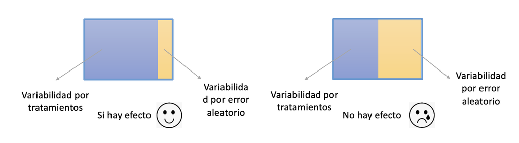

Ahora bien, el objetivo del análisis de varianza es probar la hipótesis de igualdad de los tratamientos con respecto a la media de la correspondiente variable de respuesta:

$$H_0: \mu_1=\mu_2 = ... = \mu_n =
\mu$$
$$H_1: \mu_i \neq
\mu_j \text{ para algún } i \neq j$$
la cual se puede escribir en forma equivalente en forma de efecto como:

$$H_0: \tau_1=\tau_2 = ... = \tau_k =
0$$
$$H_1: \tau_i \neq
0 \text{ para algún } i$$
donde $\tau_i$ es el efecto del tratamiento $i$ sobre la variable de respuesta. Si se acepta $H_0$, se confirma que los efectos sobre la respuesta de los $k$ tratamientos son estadísticamente nulos (iguales a cero), y en caso de rechazar se estaría concluyendo que al menos un efecto es diferente de cero.

Ahora bien, si comparamos las hipótesis para la media y para los efectos se deduce que:

$$\mu_i - \mu =\tau_i\ \ \ \ \ \ \ \
\forall i$$

Lo cual representa el efecto del tratamiento $i$,esto es la distancia entre la respuesta media del tratamiento, $\mu_i$, y la respuesta media global, $\mu$; y cuando un efecto es igual a cero, equivale a decir que la media del tratamiento correspondiente es igual a la media global. Así, se observa que para que todas las respuestas medias de tratamientos sean iguales a la respuesta media global, $\mu$, representada por la línea horizontal, se requiere que todos los efectos $\tau_i$ sean iguales a cero.

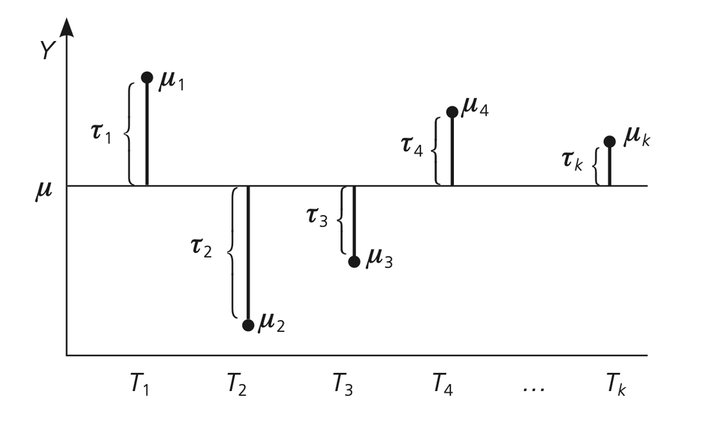

Para probar la hipótesis planteandas mediante la técnica de ANOVA, se debe separar la variabilidad total de los datos. Para ello se tiene que una medida de la variabilidad total presente en las observaciones de la siguiente tabla:

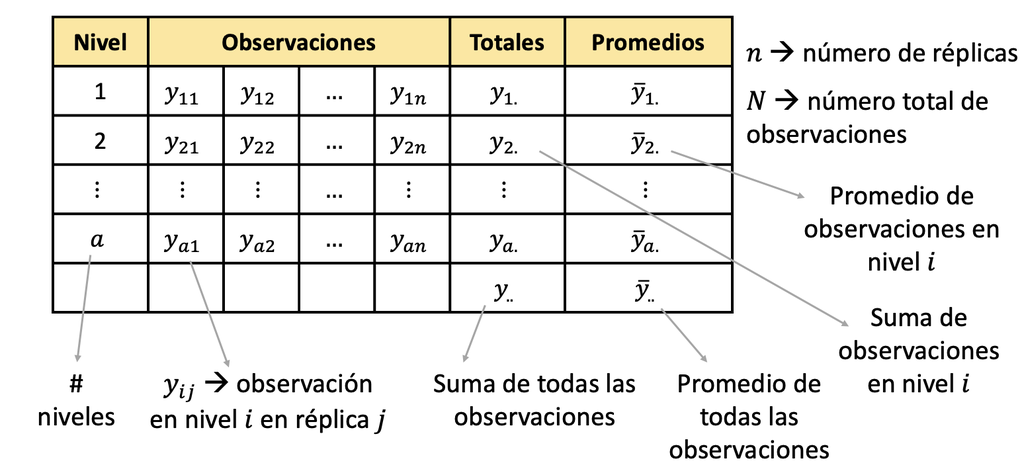

Es la suma total de cuadrados dada por:

$$SST=\sum_{i=1}^{a}\sum_{j=1}^{n_i}(y_{ij}-\overline{y}_{..})^2=\sum_{i=1}^{a}\sum_{j=1}^{n_i}y^2_{ij}-\frac{y^2_{..}}{N}$$

Por lo tanto, la partición de la variabilidad global es:

$$\sum_{i=1}^{a}\sum_{j=1}^{n_i}(y_{ij}-\overline{y}_{..})^2=n_i\sum_{i=1}^{a}(\overline{y}_{i.}-\overline{y}_{..})^2+\sum_{i=1}^{a}\sum_{j=1}^{n_i}(y_{ij}-\overline{y}_{i.})^2$$

Donde el primer componente es la suma de cuadrados de tratamientos ($SS_{Tratamiento}$) y el segundo es la suma de cuadrados del error ($SSE$). Al observar con detalle estas sumas de cuadrados, se aprecia que la $SS_{Tratamiento}$ mide la variación o diferencias entre tratamientos, ya que si éstos son muy diferentes entre sí, entonces la diferencia $y_{i.}-\overline{y}_{..}$ tenderá a ser grande en valor absoluto, y con ello también será grande la $SS_{Tratamiento}$. Por su parte, la $SSE$ mide la variación dentro de tratamientos, ya que si hay mucha variación entre las observaciones de cada tratamiento, entonces $y_{ij}-\overline{y}_{i.}$ tenderá a ser grande en valor absoluto. En forma abreviada, esta descomposición de la suma total de cuadrados se puede escribir como:

$$SST = SS_{Tratamiento}+SS_E$$

Como hay un total de N observaciones, la $SST$ tiene $N – 1$ grados de libertad. Hay $a$ tratamientos o niveles del factor de interés, así que $SS_{Tratamiento}$ tiene $a – 1$ grados de libertad, mientras que la $SS_E$ tiene $N – a$.

Por otra parte, las sumas de cuadrados divididas entre sus respectivos grados de libertad se llaman cuadrados medios, y es una estimación de la magnitud de su correspondiente fuente de variabilidad. Los dos que más interesan son el cuadrado medio de tratamientos y el cuadrado medio del error, que se denotan por:

$$MS_{tratamiento}=\frac{SS_{Tratamiento}}{a-1}$$
y,
$$MS_{E}=\frac{SS_E}{N-a}$$

Los valores esperados de los cuadrados medios están dados por:

$$E(MS_E)=\sigma^2$$
y,

En estas expresiones se aprecia que cuando la hipótesis nula es verdadera, ambos cuadrados medios estiman la varianza $\sigma^2$, ya que el segundo término de la expresión para el $E(MS_{tratamiento})$ sería igual a cero. Con base en este hecho se construye el estadístico de prueba como sigue:

$$F_0=\frac{MS_{tratamiento}}{MS_E}$$

La cual sigue una distribución $F$ de fisher con $(a – 1)$ grados de libertad en el numerador y $(N – a)$ grados de libertad en el denominador. Donde se deduce que si $F_0$ es grande, se contradice la hipótesis de que no hay efectos de tratamientos; en cambio, si $F_0$ es pequeño, se confirma la validez de $H_0$. Así, para un nivel de significancia predefinido, se rechaza $H_0$ si $F_0 > F_{\alpha, a -1, N – a}$, donde $F_{\alpha, a -1, N – a}$ es el percentil $(1 – \alpha) *100$ de la distribución F. También se rechaza $H_0$ si el $valor-p < \alpha$, donde el valor-p es el área bajo la distribución $F_{a -1, N – a}$ a la derecha del estadístico $F_0$, es decir, el valor-p = $P(F > F_0)$ es la significancia observada. Las fórmulas simplificadas para calcular el estadístico $F_0$ hasta llegar al valor-p se escribe en la llamada tabla de análisis de varianza (ANOVA) que se muestra en la siguiente tabla:

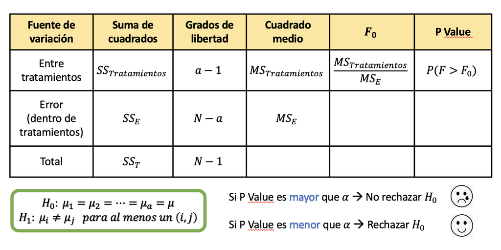

**Estimación de los parámetros**

A continuación presentamos los estimadores de los parámetros del modelo con un solo factor:

- Estimador de la media global:

$$\hat{\mu} =
\overline{y}_{..}$$

- Estimador de la media del tratamiento $i$.

$$\hat{\mu_i} =
\overline{y}_{i.}$$

- Estimador del efecto del tratamiento $i$.

$$\hat{\tau_i} = \overline{y}_{i.} -
\overline{y}_{..}$$

- Intervalo de confianza para $\mu_i$:

$$\overline{y}_{i.} -
t_{(\frac{\alpha}{2},N-a)}\sqrt{\frac{MS_E}{n}} \leq \mu_i \leq
\overline{y}_{i.} +
t_{(\frac{\alpha}{2},N-a)}\sqrt{\frac{MS_E}{n}}$$

- Intervalo de confianza para la diferencia de medias:

$$(\overline{y}_{i.}- \overline{y}_{j.})-
t_{(\frac{\alpha}{2},N-a)}\sqrt{\frac{2MS_E}{n}} \leq \mu_i -\mu_j \leq
(\overline{y}_{i.}- \overline{y}_{j.})+
t_{(\frac{\alpha}{2},N-a)}\sqrt{\frac{2MS_E}{n}}$$

## Ejemplo 1

Un ingeniero está interesado en investigar el efecto del peso porcentual del algodón sobre la resistencia a la tensión ($lb/in^2$) de una nueva fibra para fabricar tela. Se Sabe que el contenido de algodón debe variar entre 10% y 40%, así que decide probar ejemplares en cinco niveles del peso porcentual del algodón: 15, 20, 25, 30 y 35 por ciento. También decide probar cinco ejemplares en cada nivel del contenido de algodón. Los datos del experimento se presentan en la siguiente tabla:

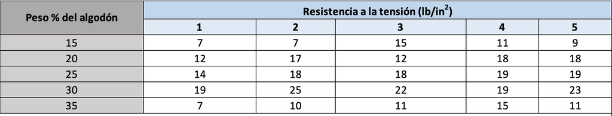

**Solución**

- **Paso 1**: Encontramos las sumas y los promedios por tratamiento, esto es: $y_{i.}$ y $\overline{y}_{i.}$. También, las sumas y promedios totales, esto es: $y_{..}$ y $\overline{y}_{..}$.

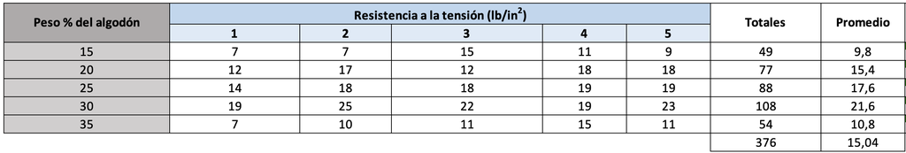

- **Paso 2**: Encontramos los $SS_{tratamiento}$ $SS_T$, y $SS_E$.

$$SS_{tratamiento} =
n_i\sum_{i=1}^{a}(\overline{y}_{i.}-\overline{y}_{..})^2=5[(9.8-15.04)^2+(15.4-15.04)^2+(17.6-15.04)^2+(21.6-15.04)^2+(10.8-15.04)^2]=475.76$$
$$SS_T=
\sum_{i=1}^{a}\sum_{j=1}^{n_i}(y_{ij}-\overline{y}_{..})^2=
(7-15.04)^2+(12-15.04)^2+ ... +(11-15.04)^2=636.96$$
$$SS_E= SS_T - SS_{tratamiento}=
636.96-475.76=161.20$$
- **Paso 3**: Hallamos los grados de libertad para cada fuente de variación anterior.

para el tratamiento:

$$a-1= 5-1= 4$$
Para el error:

$$N-a = 25-5= 20$$
Para la suma total:

$$N-1= 25-1 =24$$

- **Paso 4**: Hallamos loas cuadrados medios

$$MS_{tratamiento}=
\frac{SS_{Tratamiento}}{a-1} = \frac{475.76}{4} = 118.94$$
$$MS_{E}=\frac{SS_E}{N-a}=
\frac{161.20}{20}=8.06$$

- **Paso 5**: Hallamos $F_0$

$$F_0=\frac{MS_{tratamiento}}{MS_E}=\frac{118.94}{8.06}=14.76$$

- **Paso 6**: Hallamo el p-valor, esto es: $P(F>F_0)$, donde $F_{\alpha, a -1, N – a}$

En particular, $P(F>F_0)=0.0000091$

El resumen de los calculos realizados se muestra en la siguiente tabla:

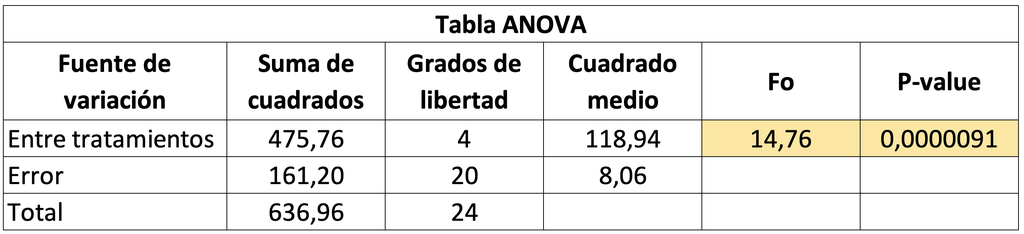

- **Paso 7**: Conclusión de los resultados

Dado que $p-valor < \alpha$, rechazamos $H_0$, es decir al menos una media es diferente.En otras palabras, el peso porcentual del algodol incide en la resistencia a la tensión.

- **Paso 8**: Estimamos los parámetros
- Estimador de la media global:

$$\hat{\mu} = \overline{y}_{..}=
15.04$$

- Estimador de la media del tratamiento $i$.

$$\hat{\mu_1} =
\overline{y}_{1.}=9.8$$
$$\hat{\mu_2}
= \overline{y}_{2.}=15.4$$
$$\hat{\mu_3} = \overline{y}_{3.}=17.6$$
$$\hat{\mu_4} = \overline{y}_{4.}=21.6$$
$$\hat{\mu_4} =
\overline{y}_{4.}=10.8$$

- Estimador del efecto del tratamiento $i$.

$$\hat{\tau_1} = \overline{y}_{1.} -
\overline{y}_{..} = 9.8 -15.04 = -5.24$$
$$\hat{\tau_2} = \overline{y}_{2.} -
\overline{y}_{..}=15.4 - 15.04 = 0.36$$
$$\hat{\tau_3} = \overline{y}_{3.} -
\overline{y}_{..}=17.6-15.04=2.56$$
$$\hat{\tau_4} = \overline{y}_{4.} - \overline{y}_{..}=
21.6-15.04=6.56$$
$$\hat{\tau_5} =
\overline{y}_{5.} - \overline{y}_{..}= 10.8 -15.04=-4.24$$

- Intervalo de confianza para $\mu_i$:

$$\overline{y}_{i.} -
t_{(\frac{\alpha}{2},N-a)}\sqrt{\frac{MS_E}{n}} \leq \mu_i \leq
\overline{y}_{i.} +
t_{(\frac{\alpha}{2},N-a)}\sqrt{\frac{MS_E}{n}}$$
Para el tratamiento 1:
$$9.8 -
2.08\sqrt{\frac{8.06}{5}} \leq \mu_1 \leq 9.8 +
2.08\sqrt{\frac{8.06}{5}}$$
$$7.15
\leq \mu_1 \leq 12.45$$
Análogamente para el tratamiento 2:

$$12.75 \leq \mu_2 \leq 18.05$$
Para el tratamiento 3:

$$14.95 \leq \mu_3 \leq 20.25$$
Para el tratamiento 4:

$$18.95 \leq \mu_4 \leq 24.25$$
Para el tratamiento 5:

$$8.15 \leq \mu_4 \leq 13.45$$

- **Usando R**

Incialmente, se construye el dataframe de los datos

```r
#Creamos el dataframe

peso <-c(15,15,15,15,15,20,20,20,20,20,25,25,25,25,25,30,30,30,30,30,35,35,35,35,35)
resistencia <-c(7,7,15,11,9,12,17,12,18,18,14,18,18,19,19,19,25,22,19,23,7,10,11,15,11)

datos<-data.frame(peso,resistencia)
datos$peso <- as.factor(datos$peso)

#Mostramos la estructura de los datos
str(datos)
```

```
## 'data.frame':    25 obs. of  2 variables:
##  $ peso       : Factor w/ 5 levels "15","20","25",..: 1 1 1 1 1 2 2 2 2 2 ...
##  $ resistencia: num  7 7 15 11 9 12 17 12 18 18 ...
```

Antes de iniciar la etapa de la construcción del anova, en R podemos revisar descriptivamente si hay una diferencia entre las medias de los niveles estudiantes, esto es:

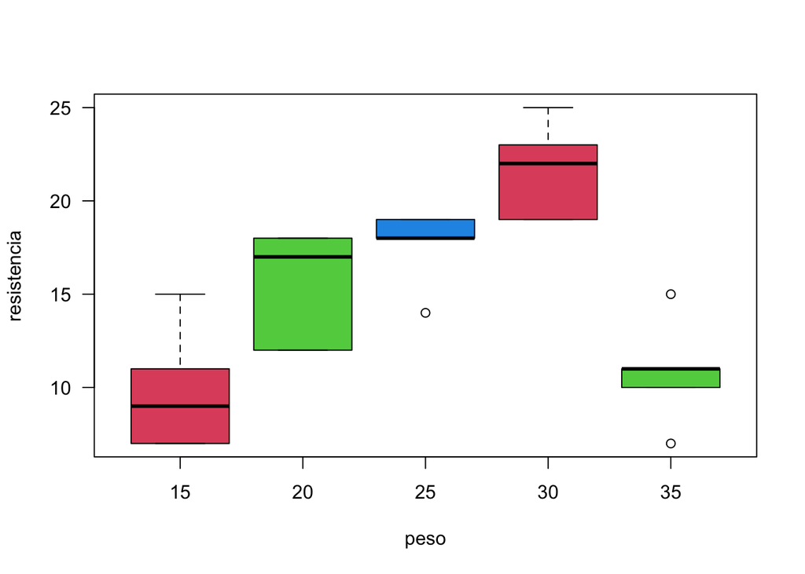

```r
## boxplots para revisar efectos
boxplot(resistencia ~ peso, data = datos, las = 1, col = 2:4, xlab = 'peso', ylab = 'resistencia')
```

Tal como se observa en el gráfico, se puede sospechar que hay diferencias entre los niveles del factor Peso.

Ahora construimos la tabla ANOVA:

```r
## ANOVA
fitdisplay <- lm(resistencia ~ peso, data = datos)
anova(fitdisplay)
```

```
## Analysis of Variance Table
##
## Response: resistencia
##           Df Sum Sq Mean Sq F value    Pr(>F)
## peso       4 475.76  118.94  14.757 9.128e-06 ***
## Residuals 20 161.20    8.06
## ---
## Signif. codes:  0 '***' 0.001 '**' 0.01 '*' 0.05 '.' 0.1 ' ' 1
```

La conclusión de la tabla ANOVA es que existe al menos un tipo de porcentaje de peso para el que las resitencias promedio son superiores o inferiores a los demás. En otras palabras, esto indica que la variable peso si afecta las resistencias del producto de interes. Aunque este resultado es importante, por lo general interesa determinar la magnitud del efecto de cada nivel de peso sobre la resistencia. Esto es posible a partir del objeto fitdisplay. Para ello utilizamos los estimadores de máxima verosimilitud obtenidos al emplear el método de mínimos cuadrados ordinarios en el modelo regresión Lineal Simple:

```r
## lineal regression
summary(fitdisplay)
```

```
##
## Call:
## lm(formula = resistencia ~ peso, data = datos)
##
## Residuals:
##    Min     1Q Median     3Q    Max
##   -3.8   -2.6    0.4    1.4    5.2
##
## Coefficients:
##             Estimate Std. Error t value Pr(>|t|)
## (Intercept)    9.800      1.270   7.719 2.02e-07 ***
## peso20         5.600      1.796   3.119 0.005409 **
## peso25         7.800      1.796   4.344 0.000315 ***
## peso30        11.800      1.796   6.572 2.11e-06 ***
## peso35         1.000      1.796   0.557 0.583753
## ---
## Signif. codes:  0 '***' 0.001 '**' 0.01 '*' 0.05 '.' 0.1 ' ' 1
##
## Residual standard error: 2.839 on 20 degrees of freedom
## Multiple R-squared:  0.7469, Adjusted R-squared:  0.6963
## F-statistic: 14.76 on 4 and 20 DF,  p-value: 9.128e-06
```

Ahora bien, para estimar el estimador de la media global, estimador del efecto del tratamiento $i$, y estimador del efecto del tratamiento $i$. Se sigue lo siguiente:

```r
#Calculamos las medias (Estimadores por tratamiento)
## measures using tapply
with(datos, tapply(resistencia, peso, mean))
```

```
##   15   20   25   30   35
##  9.8 15.4 17.6 21.6 10.8
```

```r
#Efectos de cada tratamiento
with(datos, tapply(resistencia, peso, mean))-mean(datos$resistencia)
```

```
##    15    20    25    30    35
## -5.24  0.36  2.56  6.56 -4.24
```

```r
#Media Global
mean(datos$resistencia)
```

```
## [1] 15.04
```

Que podemos decir acerca de la comparación de los diferentes pesos Para responder a esto utilizamos una comparación ad hoc. Esta comparación puede hacerse utilizando la prueba de mínima diferencia significativa de Tukey:

```r
## Least Singificant Difference (LSD) test
anova <- aov(fitdisplay)
(lsd <- TukeyHSD(anova, "peso", ordered = TRUE))
```

```
##   Tukey multiple comparisons of means
##     95% family-wise confidence level
##     factor levels have been ordered
##
## Fit: aov(formula = fitdisplay)
##
## $peso
##       diff        lwr       upr     p adj
## 35-15  1.0 -4.3729583  6.372958 0.9797709
## 20-15  5.6  0.2270417 10.972958 0.0385024
## 25-15  7.8  2.4270417 13.172958 0.0025948
## 30-15 11.8  6.4270417 17.172958 0.0000190
## 20-35  4.6 -0.7729583  9.972958 0.1162970
## 25-35  6.8  1.4270417 12.172958 0.0090646
## 30-35 10.8  5.4270417 16.172958 0.0000624
## 25-20  2.2 -3.1729583  7.572958 0.7372438
## 30-20  6.2  0.8270417 11.572958 0.0188936
## 30-25  4.0 -1.3729583  9.372958 0.2101089
```

Los resultados indican que la diferencia 20-15, 25-15, 30-15, 25-35, 30-35, y 30-20 son estadísticamente significativas después de correcciones por múltiples comparaciones, es decir, que la columna p-adj es < 0.05, donde este último valor corresponde a la probabilidad de Error Tipo I.

Para visualizar dichas diferencias utilizamos la función plot sobre el objeto lsd:

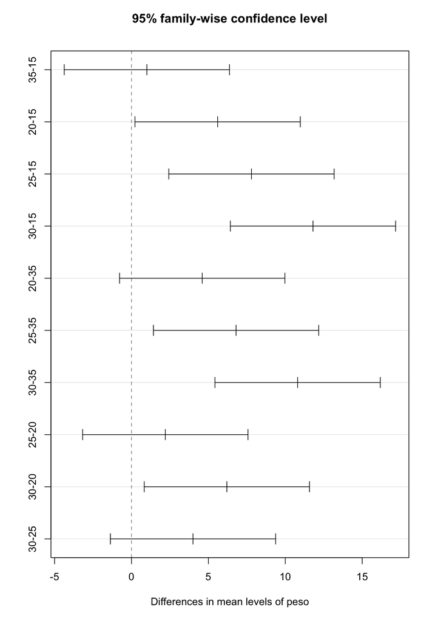

```r
## LSD plot
plot(lsd)
```

La conclusión es la misma que obtuvimos al analizar los resultados numéricos.

Finalmente, los intervalos de confianza se pueden calcular con el siguiente código para cada tratamiento:

```r
## Intervalos de confianza

calcular_intervalo_confianza <- function(promedio,mse,grados_libertad,n, confianza = 0.95) {
  error_estandar <- sqrt(mse/n)
  t_valor <- qt((1 + confianza) / 2, df = grados_libertad)  # Valor crítico de t

  margen_error <- t_valor * error_estandar
  limite_inferior <- promedio - margen_error
  limite_superior <- promedio + margen_error

  return(c(limite_inferior, limite_superior))
}
resumen_modelo<-summary(fitdisplay)
mse <-resumen_modelo$sigma^2
promedio <- with(datos, tapply(resistencia, peso, mean))
n <- 5
grados_libertad <- 20

for (i in 1:n) {
  intervalos_confianza<-calcular_intervalo_confianza(promedio[i],mse,grados_libertad,n)
  cat("Intervalo de confianza para el tratamiento", i,": [",intervalos_confianza[1],",",intervalos_confianza[2], "]\n")
}
```

```
## Intervalo de confianza para el tratamiento 1 : [ 7.151566 , 12.44843 ]
## Intervalo de confianza para el tratamiento 2 : [ 12.75157 , 18.04843 ]
## Intervalo de confianza para el tratamiento 3 : [ 14.95157 , 20.24843 ]
## Intervalo de confianza para el tratamiento 4 : [ 18.95157 , 24.24843 ]
## Intervalo de confianza para el tratamiento 5 : [ 8.151566 , 13.44843 ]
```

# Supuestos

La validez de los resultados obtenidos en cualquier análisis de varianza queda supeditado a que los supuestos del modelo se cumplan. Estos supuestos son: normalidad, varianza constante (igual varianza de los tratamientos) e independencia. Esto es, la respuesta ($Y$) en cada tratamiento se debe distribuir de manera normal, con la misma varianza en cada tratamiento, y las mediciones deben ser independientes. Estos supuestos sobre $Y$ se traducen en supuestos sobre el término error ($\varepsilon$) en el mo- delo.Es una práctica común utilizar la muestra de residuos para comprobar los supuestos del modelo, ya que si los supuestos se cumplen, los residuos o residuales se pueden ver como una muestra aleatoria de una distribución normal con media cero y varianza constante. Los residuos, $\varepsilon_{ij}$, se definen como la diferencia entre la respuesta observada ($y_{ij}$) y la respuesta predicha por el modelo ($\widehat{y_{ij}}$), lo cual permite hacer un diagnóstico más directo de la calidad del modelo, ya que su magnitud señala qué tan bien el modelo describe los datos.

En general, En DOE de un factor al igual que los otros DOE, se tienen los siguientes supuestos sobre el error aleatorio, $\varepsilon$:

1. $\mu_\varepsilon= 0$, donde $\mu_\varepsilon$ es la media de $\varepsilon$. (Linealidad)
2. $\varepsilon_1, \varepsilon_2, ... , \varepsilon_n$ tiene varianza constante $\sigma^2$ (Homocedasticidad)
3. $\varepsilon \sim N(0,\sigma^2)$ (Normalidad)
4. $\varepsilon_i$ y $\varepsilon_j$ son independientes para $i \neq j$

En R dicha validación se realiza sobre los residuales del modelo ajustado. En nuestro caso, este modelo está contenido en el objeto fitdidisplays.

```r
require(car)
## calcular los residuals
r <- rstudent(fitdisplay)
```

## Normalidad

Para la prueba de normalidad de utiliza el Q-Q plot y la prueba de Shapiro-Wilk. En el caso del plot Q-Q se debe observar que los puntos sigan la línea recta para comprobar la normalidad en los residuos. Para el Caso del Test de Shapiro-Wilk se valida que $H_0:$ Los datos proceden de una distribución normal, donde se concluye que sigue una distribución normal si el $P-value > \alpha$.

```r
## Supuesto de  normalidad
shapiro.test(r)
```

```
##
##  Shapiro-Wilk normality test
##
## data:  r
## W = 0.9484, p-value = 0.2306
```

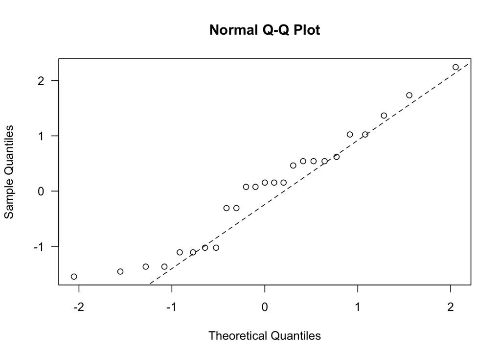

```r
#Graficamente
qqnorm(r, las = 1)
qqline(r, col = 1, lty = 2)
```

## Homocedasticidad

Para el caso de la prueba de varianza constate (Homocedasticidad), se utiliza el test de Barlett, Donde se valida $H_0:$ la varianza es constante, donde se concluye qe hay homocedasticidad en los residuos si el $P-value > \alpha$.

```r
## varianza constante usando Breusch-Pagan
car:::ncvTest(fitdisplay)
```

```
## Non-constant Variance Score Test
## Variance formula: ~ fitted.values
## Chisquare = 0.4761503, Df = 1, p = 0.49017
```

```r
bartlett.test(datos$resistencia ~ datos$peso)
```

```
##
##  Bartlett test of homogeneity of variances
##
## data:  datos$resistencia by datos$peso
## Bartlett's K-squared = 0.93309, df = 4, p-value = 0.9198
```

Para este caso en particula, se cumple el supuesto de homocedasticidad, dado a que p-values es igual a 0.919

## Independencia de los errores

Una prueba analítica para verificar la independencia entre residuos consecutivos es la prueba de Durbin-Watson. Para validar el suspuesto de independencia de errores en los residuos el $P-value > \alpha$.

```r
## Durbin-Watson (Prueba de independencia dee errores)
durbinWatsonTest(fitdisplay)
```

```
##  lag Autocorrelation D-W Statistic p-value
##    1      -0.2255583      2.402233   0.872
##  Alternative hypothesis: rho != 0
```

Gráficamente, podemos validar los supuestos con los siguientes plots:

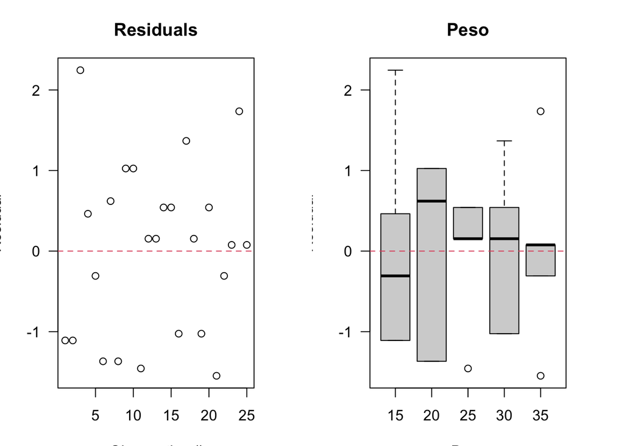

```r
# r vs. x1
par(mfrow = c(1, 2), mai = c(0.65, 0.65, .65, .65))
plot(r, las = 1, ylab = 'Residual', xlab = "Observation #", main = 'Residuals')
abline(h = 0, col = 2, lty = 2)
# r vs. x3
boxplot(r ~ datos$peso, las = 1, ylab = 'Residual', xlab = "Peso", main = "Peso")
abline(h = 0, col = 2, lty = 2)
```

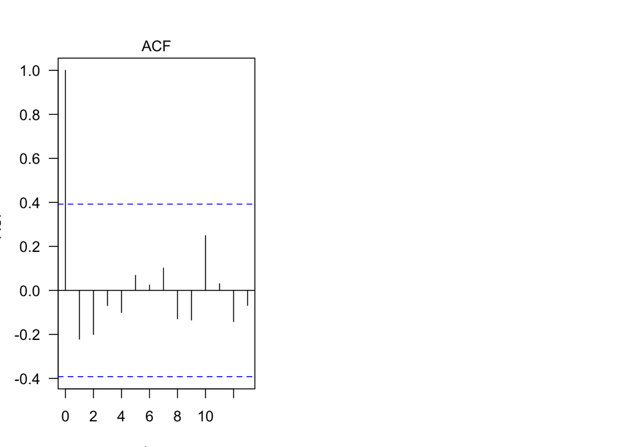

```r
## independence using ACF
acf(r, las = 1, main = "")
mtext("ACF", side = 3, line = .2)
```

Estos resultados indican que los errores del modelo ajustado son independientes, siguen una distribución normal y tienen varianza constante. Por lo tanto, el modelo y las conclusiones que se deriven de él son valida.